# Figure 6 Notebook: Statistical Analysis of Public Mtb Genomes and generation of Oxidative Stress Response (OSR) Network

**Author: Evan Pepper-Tunick**

Last updated: Mar 26, 2026

This notebook is for analyzing the variants identified in the Mtb clinical isolate dataset using a Bayesian probability framework and temporal analysis of Mtb evolution in the context of drug resistance mutations. This dataset includes isolates from: Silcocks et al. 2023

WGS data was processed and analyzed using an adaptation of the variant calling pipeline from Liu et al. 2022, which can be found at: https://github.com/baliga-lab/bwa_pipeline. Details on specific pipeline parameters for calling mutations and use of TB-Profiler can be found in the Methods section.

One important file analyzed here is not included in this work. **This file will be needed to run all of the code in this notebook.** The file is: – CRISPRi strains during various drug treatments from S. Li et. al. 2022. This is Source Data Fig. 1 from this publication and can be downloaded at: 10.1038/s41564-022-01130-y

**Important note: to run notebook, user’s computer must have ≥ 12.0 GB memory**

```r
# importing necessary libraries
suppressMessages(
  {
  library(ggplot2)
  library(ggridges)
  library(ggupset)
  library(tidyverse)
  library(purrr)
  library(drc)
  library(knitr)
  library(factoextra)
  library(naniar)
  library(rstatix)
  library(ggpubr)
  library(scales)
  library(ggrepel)
  library(see)
  library(viridis)
  library(seqinr)
  library(Biostrings)
  }
)

# setting plot theme attributes
plot.theme <- theme(title = element_text(size = 14),
                    axis.text = element_text(size = 12),
                    axis.title = element_text(size = 12),
                    legend.title = element_text(size = 10),
                    legend.text = element_text(size = 8),
                    strip.text = element_text(size = 10))
```

```r
#################################################################################
# writing a function to calculate bayes probability
calculateBayes <- function(total.n, total.n.with.a, total.n.with.b, total.n.with.a.and.b) {
  # Calculate the conditional probability P(A|B)
  bayes.prob <- total.n.with.a.and.b / total.n.with.b
  return(bayes.prob)
}
# function for using apply to get bayes probs for each locus
calculateMetrics <- function(count.table, phenotypes) {
  # Get the sample IDs with mutations (non-zero counts)
  isomut <- colnames(count.table)[apply(count.table, 2, function(x) any(x > 0))]
  isolate.with.mutation.n <- length(isomut)
  # Get the count of resistant isolates with mutations
  R.isolate.n.with.mutation <- sum(resistant_isolates %in% isomut)
  # Calculate the Bayes probability
  bayes.prob <- calculateBayes(isolate.n, R.isolate.n, isolate.with.mutation.n, R.isolate.n.with.mutation)
  return(bayes.prob)
}
# function for converting matrix of isolate IDs and mutations to wide form
flattenCounts <- function(isolate.locus.matrix) {
  # transforming table to wide form with SNP occurances
  count.table.wide <- isolate.locus.matrix %>%
    group_by(Sample.ID, Locus) %>%
    summarise(n = n(), .groups = 'drop') %>%
    pivot_wider(names_from = Sample.ID, values_from = n, values_fill = list(n = 0))
  # convert to dataframe
  count.table.wide <- as.data.frame(count.table.wide)
  count.table.wide <- count.table.wide[complete.cases(count.table.wide), ]
  # set rownames and remove locus column
  rownames(count.table.wide) <- count.table.wide$Locus
  count.table.wide <- count.table.wide %>% dplyr::select(-Locus)
  return(count.table.wide)
}
#################################################################################
```

```r
# reading in metadata for clinical isolates with variants called
# THIS PHENOTYPES FILE CAN BE AVAILABLE UPON REQUEST
phenotypes <- read_csv(file = '../data/Fig6/dst-isolates/dst-isolate-phenotypes.csv')
genotypes <- read_csv(gzfile('../data/Fig6/dst-isolates/dst-isolate-locus-matrix.csv.gz'))
names(genotypes) <- c('Sample.ID', 'Locus')
# insuring phenotype data only contains samples with variant data
phenotypes <- phenotypes %>% filter(Sample.ID %in% unique(genotypes$Sample.ID))
mtb.gene.map <- read_csv(file = '../data/genome-annotations/mtb-h37rv-full-genome-annotation.csv', show_col_types = FALSE)
gene.name.conversion.table <- read_csv(file = '../data/genome-annotations/gene-locus-map.csv')

# removing outlier from phylogeny analysis
outlier.id <- phenotypes %>% filter(major.lineage == 8) %>% pull(Sample.ID)
phenotypes <- phenotypes %>% filter(Sample.ID != outlier.id)
genotypes <- genotypes %>% filter(Sample.ID != outlier.id)
```

```r
# getting summary of lineages and resistance profiles for plotting
# generating bar plot of sizes of each lineage
phenotypes$major.lineage <- factor(phenotypes$major.lineage, levels = c(1, 2, 4))
lineages.summarized <- phenotypes %>% group_by(major.lineage) %>% tally() %>% filter(!is.na(major.lineage))
```

```r
# lineage counts
lineage.counts <- ggplot(lineages.summarized, aes(x = major.lineage, y = n, fill = major.lineage)) +
  geom_bar(stat = "identity", color = 'black') +
  geom_text(aes(label = n), nudge_y = 0.25, size = 5) +
  scale_y_log10() +
  xlab('Major Lineage') + ylab('Sample Count') +
  theme_minimal() +
  plot.theme +
  theme(legend.position = 'none')
```

```r
pdf(file = '../figures/figure-panels/fig6-panel-a.pdf', height = 4, width = 3)
print(lineage.counts)
dev.off()
```

**Figure 6 Panel A**

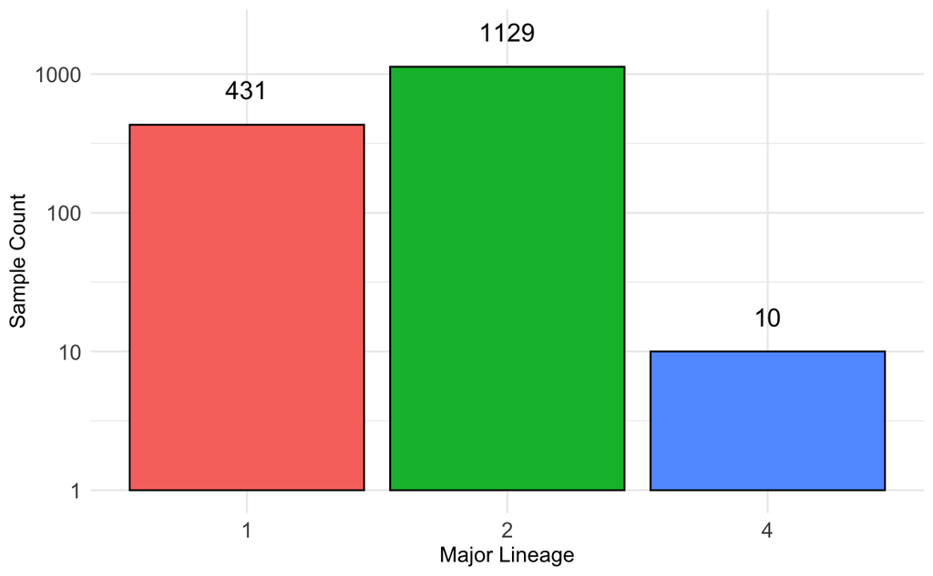

```r
lineage.counts
```

```r
# preparing data from genotype calls to make summary figure for mutations in dataset
full.genotype.calls <- read_csv(gzfile('../data/Fig6/dst-isolates/dst-isolate-genotypes-all-pipelines-filtered.csv.gz'))
# full.genotype.calls <- read_csv(gzfile('../data/Fig6/dst-isolates/dst-isolate-genotypes.csv.gz'))
# cleaning up effect column for summarizing
full.genotype.calls.effect.change <- full.genotype.calls %>%
  filter(EFFECT %in% c('Intergenic', 'Nonsynonymous')) %>%
  mutate(EFFECT = case_when(EFFECT == 'Intergenic' ~ 'INTERGENIC',
                            EFFECT == 'Nonsynonymous' ~ 'NONSYNONYMOUS'))

full.genotypes <- rbind(full.genotype.calls %>% filter(!EFFECT %in% c('Intergenic', 'Nonsynonymous', 'EXON',
                                                                      'GENE_FUSION', 'GENE_FUSION_REVERESE')),
                        full.genotype.calls.effect.change)
full.genotypes <- full.genotypes %>%
  mutate(EFFECT = case_when(EFFECT == 'CODON_CHANGE_PLUS_CODON_DELETION' ~ 'INFRAME\nDELETION',
                            EFFECT == 'CODON_CHANGE_PLUS_CODON_INSERTION' ~ 'INFRAME\nINSERTION',
                            EFFECT == 'CODON_DELETION' ~ 'INFRAME\nDELETION',
                            EFFECT == 'CODON_INSERTION' ~ 'INFRAME\nINSERTION',
                            EFFECT == 'FRAME_SHIFT' ~ 'FRAME SHIFT',
                            EFFECT == 'NON_SYNONYMOUS_CODING' ~ 'MISSENSE',
                            EFFECT == 'NONSYNONYMOUS' ~ 'MISSENSE',
                            EFFECT == 'INTERGENIC' ~ 'INTERGENIC',
                            EFFECT == 'START_LOST' ~ 'START LOST',
                            EFFECT == 'STOP_GAINED' ~ 'STOP GAINED',
                            EFFECT == 'STOP_LOST' ~ 'STOP LOST'
                            ))
# tallying up calls for manuscript
n.fixed <- nrow(full.genotypes %>% filter(FREQ >= 90))
n.unfixed <- nrow(full.genotypes %>% filter(FREQ < 90))

n.nonsyn <- nrow(full.genotypes %>% filter(EFFECT != 'INTERGENIC'))
n.intergenic <- nrow(full.genotypes %>% filter(EFFECT == 'INTERGENIC'))
# to identify XX fixed and YY unfixed (at least 10% alternative allele frequency) mutations (XX intergenic and YY nonsynonymous protein-coding mutations) across 5,233 genomic loci within each sample
print(paste('We identified ', n.fixed, ' fixed mutations and ', n.unfixed, ' unfixed mutations', sep = ''))
```

```
[1] "We identified 1140577 fixed mutations and 194263 unfixed mutations"
```

```r
print(paste('Across all variants, ', n.intergenic, ' were intergenic and ', n.nonsyn, ' were nonsynonymous', sep = ''))
```

```
[1] "Across all variants, 316823 were intergenic and 1018017 were nonsynonymous"
```

```r
# creating figure 6 panel c
# summary of mutations in dataset
variant.summary.data <- full.genotypes %>%
  group_by(EFFECT, PIPELINE) %>% tally() %>% arrange(desc(n))

variant.summary.data$EFFECT <- factor(variant.summary.data$EFFECT, levels = c(unique(variant.summary.data$EFFECT)))

# write_csv(variant.summary.data, file = '../data/Fig6/dst-isolates/variant-count-table.csv')

variant.summary <- ggplot(variant.summary.data, aes(x = EFFECT, y = n, fill = PIPELINE)) +
  geom_bar(position = position_dodge(width = 0.9), stat = "identity", color = 'black', alpha = 0.2) +
  geom_text(aes(label = n), nudge_y = 0.25, size = 4) +
  scale_fill_manual(values = c('white', 'purple')) +
  scale_y_log10() +
  xlab('') + ylab('Variant Count') +
  theme_minimal() +
  plot.theme +
  theme(legend.position = 'none',
        axis.text.x = element_text(angle = 45, size = 8))
```

```r
pdf(file = '../figures/figure-panels/fig6-panel-c.pdf', height = 4.4, width = 5)
print(variant.summary)
dev.off()
```

**Figure 6 Panel C**

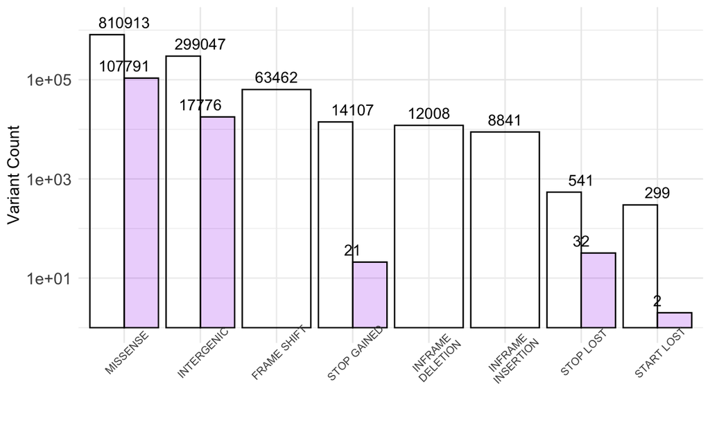

```r
variant.summary
```

```r
# preparing data for upset plot for RIPE (RIF, INH, PZA, EMB)
# selecting columns of interest
status.data <- phenotypes %>%
  select(Sample.ID, Rifampicin, Isoniazid, Ethambutol, Streptomycin)
# making sure all values are either 1 or 0 (no NAs)
status.data <- replace(status.data, is.na(status.data), 0)
# creating vector of unique sample names
sample.ids <- status.data$Sample.ID
# creating a vector of all antibiotic names
abxs <- colnames(status.data[, 2:ncol(status.data)])
# for loop for getting abx name for all row values = 1 for each sample
sample.spectrums <- list()
for (i in 1:length(status.data$Sample.ID)) {
  spectrum.list <- list()
  sample <- status.data[i, 2:ncol(status.data)]
  if (sum(sample) == 0) {
    spectrum.list[i] <- NA
  }
  else {
    for (k in 1:length(abxs)) {
      if (sample[k] == 1) {
        spectrum.list[k] <- abxs[k]
      }
    }
  }

  sample.spectrums[[i]] <- unlist(spectrum.list)
}
# add list of resistance spectrum for each isolate to data as a new column
status.data$spectrum <- sample.spectrums
```

```r
# making upset plot
status.data.filtered <- status.data %>% distinct(Sample.ID, .keep_all = TRUE)
status.data.tally <- status.data.filtered %>% group_by(spectrum) %>% tally() %>% arrange(desc(n))
status.data.tally$spectrum <- unlist(lapply(status.data.tally$spectrum, function(x) ifelse(is.null(x), NA, x)))
```

```r
write_csv(status.data.tally, file = '../data/Fig6/susceptibility-profile-counts.csv')
```

```r
upset.plot <- ggplot(status.data.filtered, aes(x = spectrum)) +
  geom_bar(fill = 'tomato4', color = 'black') +
  scale_x_upset(n_intersections = 8) +
  scale_y_log10() +
  xlab('') + ylab('') +
  theme_minimal() +
  theme_combmatrix(combmatrix.label.text = element_text(size = 12),
                   combmatrix.panel.point.color.fill = "tomato3",
                   combmatrix.panel.point.size = 5,
                   combmatrix.panel.line.size = 0) +
  plot.theme
```

```r
pdf(file = '../figures/figure-panels/fig6-panel-b.pdf', height = 3.75, width = 6)
print(upset.plot)
dev.off()
```

```r
upset.plot
```

[output not shown]

```r
# creating mutation counts for multi-locus sites
# each for loop checks for a unique combination of loci using 'and' / 'or' logic
genotype.isolates <- unique(genotypes$Sample.ID)
# mshA or mshC
sample.id.calls.1 <- list()
for (g in 1:length(genotype.isolates)) {
  isolate.data <- genotypes %>% filter(Sample.ID == genotype.isolates[g])
  if ('mshA' %in% isolate.data$Locus | 'mshC' %in% isolate.data$Locus) {
     sample.id.calls.1[[g]] <- tibble(Sample.ID = isolate.data$Sample.ID[1], Locus = 'mshA|mshC')
  }
  else {
    next
  }
}
extra.genotype.calls.1 <- do.call(rbind, sample.id.calls.1)
# mshA or mshB or mshC or mshD
sample.id.calls.2 <- list()
for (g in 1:length(genotype.isolates)) {
  isolate.data <- genotypes %>% filter(Sample.ID == genotype.isolates[g])
  if ('mshA' %in% isolate.data$Locus | 'mshB' %in% isolate.data$Locus | 'mshC' %in% isolate.data$Locus | 'mshD' %in% isolate.data$Locus) {
    sample.id.calls.2[[g]] <- tibble(Sample.ID = isolate.data$Sample.ID[1], Locus = 'mshA|mshB|mshC|mshD')
  }
  else {
    next
  }
}
extra.genotype.calls.2 <- do.call(rbind, sample.id.calls.2)

# binding to existing genotype data
genotypes <- rbind(genotypes, extra.genotype.calls.1, extra.genotype.calls.2) %>% arrange(Sample.ID)
```

```r
# calculating bayes probabilities and using output from NullBayesGlobal.R to read in null distributions for p value calculation
isolate.n <- nrow(phenotypes)
#################################################################################
# flattening SNP data to prepare for calculations
print('widening data (global)')
system.time(snp.data.wide <- flattenCounts(genotypes))
print('data widened (global)')
#################################################################################
# setting major values
# Get the sample IDs of isolates that are resistant to Isoniazid
resistant_isolates <- phenotypes %>%
  filter(Sample.ID %in% colnames(snp.data.wide) & Isoniazid == 1) %>%
  pull(Sample.ID)
R.isolate.n <- length(resistant_isolates)
#################################################################################
print('computing bayes probabilities (global)')
system.time(bayes <- data.frame(sapply(1:nrow(snp.data.wide), function(x){ calculateMetrics(snp.data.wide[x, ], phenotypes) })))
print('done computing bayes probabilities (global)')
names(bayes) <- 'bayes'
bayes$locus <- rownames(snp.data.wide)
bayes <- bayes %>% arrange(desc(bayes))
```

```r
write_csv(bayes, file = '../data/Fig6/LDF/bayes-probabilities/INH-Global.csv')
#################################################################################
```

```r
bayes <- read_csv(file = '../data/Fig6/LDF/bayes-probabilities/INH-Global.csv', show_col_types = FALSE)
path.to.nulls <- '../data/Fig6/LDF/bayes-null-distributions/INH-global-download'
# aggregating null distribution data
null.files <- list.files(path = path.to.nulls)
null.dists <- list()
print('reading in nulls (global)')
#for (i in 1:100) {
for (i in 1:length(null.files)) {
  null.dists[[i]] <- read_csv(file = paste(path.to.nulls, '/', null.files[i], sep = ''), show_col_types = FALSE)
}
null.bayes <- do.call(rbind, null.dists)
print('done reading in all nulls (global)')
```

```r
# visualizing null distributions
distributions <- ggplot(bayes, aes(x = bayes)) +
  geom_histogram(binwidth = 0.004, fill = 'red', alpha = 0.8) +
  geom_density(data = null.bayes, aes(x = bayes), fill = 'black', alpha = 0.4) +
  geom_vline(xintercept = min(null.bayes$bayes), linetype = 'dashed') +
  geom_vline(xintercept = max(null.bayes$bayes), linetype = 'dashed') +
  geom_vline(xintercept = mean(null.bayes$bayes)) +
  annotate(geom = 'text', x = (mean(null.bayes$bayes) + 0.05), y = (length(null.files) / 25),
           label = paste('mean\n', round(mean(null.bayes$bayes), digits = 4), sep = '')) +
  xlab('Bayes Probabilities') + ylab('') +
  ggtitle(paste('Bayes Probabilities for INH resistance (red)\nNull probability distribution, Global DST isolates,\n', length(null.files), ' iterations (black)', sep = '')) +
  theme_minimal() +
  plot.theme
```

```r
distributions
```

```r
# generating p values for bayes probabilities
p.values <- list()
for (b in 1:nrow(bayes)) {
  locus <- bayes[b, ]
  bayes.value <- locus$bayes
  # getting p value by comparing bayes probability to the null distribution
  # how many values in the null are smaller than the calculated bayes probability
  n.null.less.than <- length(which(null.bayes$bayes < bayes.value))
  # case when bayes probability is less than all null values
  if (n.null.less.than == 0) {
    p.value <- 1
  }
  else {
    # p value is equal to 1 minus the proportion of all random bayes values less than computed bayes value
    p.value <- 1 - ( n.null.less.than / nrow(null.bayes) )
  }
  p.values[b] <- p.value
}
# adding p values back to data
bayes$p.value <- unlist(p.values)
bayes$adj.p.value <- p.adjust(bayes$p.value, method = 'fdr')
```

```r
write_csv(bayes, file = '../data/Fig6/LDF/bayes-probabilities/INH-Global-PValues.csv')
```

```r
info.table <- tibble(lineage = 'Global',
                     n.isolates = isolate.n,
                     n.inhR.isolates = R.isolate.n,
                     prop.inhR = (R.isolate.n / isolate.n),
                     mean.null = mean(null.bayes$bayes),
                     n.significant.loci = nrow(bayes %>% filter(adj.p.value <= 0.01)))
```

Reading in calculated bayes probabilities with p values

```r
bayes <- read_csv(file = '../data/Fig6/LDF/bayes-probabilities/INH-Global-PValues.csv', show_col_types = FALSE)
```

Creating part of Figure 6D

```r
ridges <- ggplot(bayes, aes(x = bayes)) +
  geom_density(alpha = 0.2, fill = 'black', linewidth = 0.25) +
  #scale_fill_manual(values = c('black', '#f37066', '#c9942c', '#76ac42', '#14b360')) +
  scale_y_discrete(expand = c(0, 0)) +
  scale_x_continuous(expand = c(0, 0), breaks = scales::pretty_breaks(n = 10)) +
  theme_minimal() +
  xlab('') + ylab('') +
  theme(legend.position = 'none')
```

```r
pdf(file = '../figures/figure-panels/fig6-panel-d.pdf', height = 3.75, width = 6)
print(ridges)
dev.off()
```

```r
ridges
```

[output not shown]

```r
# Creating density plot for null distribution to overlay
null.bayes.sample <- sample_n(null.bayes, 100000, replace = F)
significance.threshold <- tail(bayes %>% filter(adj.p.value <= 0.05), n = 1) %>% pull(bayes)

null <- ggplot(null.bayes.sample, aes(x = bayes)) +
  geom_density(linewidth = 0.5, linetype = 'dashed', color = 'gray50', fill = 'NA') +
  geom_vline(xintercept = info.table$mean.null, linetype = 'dashed', color = 'black', alpha = 0.5) +
  geom_vline(xintercept = significance.threshold, linetype = 'dashed', color = 'red', alpha = 0.5) +
  scale_y_discrete(expand = c(0, 0)) +
  scale_x_continuous(expand = c(0, 0), breaks = scales::pretty_breaks(n = 10), limits = c(0, 1)) +
  theme_minimal() +
  xlab('') + ylab('') +
  theme(legend.position = 'none',
        panel.grid.major = element_blank(),
        panel.grid.minor = element_blank(),
        axis.text.x = element_text(size = 0),
        axis.text.y = element_text(size = 0))
```

```r
pdf(file = '../figures/figure-panels/fig6-panel-d-null.pdf', height = 2, width = 6)
print(null)
dev.off()
```

Assessing Bayes probabilities amongst loci known or likely to be associated INH resistance. Loci included in analysis are from: 10.1128/microbiolspec.mgm2-0014-2013

```r
# creating list of INH resistance associated loci
inhR.loci.list <- c('oxyR-ahpC', 'Rv2427A-Rv2428',
                    'ahpC', 'Rv2428',
                    'oxyR', 'Rv2427A',
                    'furA', 'Rv1909c',
                    'katG', 'Rv1908c',
                    'furA-katG', 'katG-furA', 'Rv1909c-Rv1908c', 'Rv1908c-Rv1909c',
                    'fabG-inhA', 'inhA-fabG', 'Rv1483-Rv1484', 'Rv1484-Rv1483',
                    'inhA', 'Rv1484',
                    'kasA', 'Rv2245',
                    'ndh', 'Rv1854c',
                    'ndhA', 'Rv0392c',
                    'iniB', 'Rv0341',
                    'iniA', 'Rv0342',
                    'iniC', 'Rv0343',
                    'Rv0340',
                    'nat', 'Rv3566c',
                    'Rv1592c',
                    'fadE24', 'Rv3139',
                    'Rv1772',
                    'efpA', 'Rv2846c',
                    'fabD', 'Rv2243',
                    'accD6', 'Rv2247',
                    'fbpC', 'Rv0129c')

bayes.inhR.loci <- bayes %>% filter(locus %in% inhR.loci.list)
```

Also assessing if there is an enrichment of intergenic loci amongst the significant Bayes probabilities

```r
# getting list of all loci with mutations to get population size and population successes
all.loci <- unique(bayes$locus)
n.total <- length(all.loci)
n.intergenic.total <- length(all.loci[grepl('-', all.loci)])
# getting sample size and sample successes
n.significant.loci <- length(unique(bayes %>% filter(adj.p.value <= 0.05) %>% pull(locus)))
n.significant.genic.loci <- length(unique(bayes[!grepl('-', bayes$locus), ] %>% filter(adj.p.value <= 0.05) %>% pull(locus)))
n.significant.intergenic.loci <- length(unique(bayes[grepl('-', bayes$locus), ] %>% filter(adj.p.value <= 0.05) %>% pull(locus)))

# performing hypergeometric test to calculate significance of enrichment of intergenic loci amonst significant hits
p.value <- phyper(q = (n.significant.intergenic.loci - 1),
                  m = n.intergenic.total,
                  n = ( n.total - n.intergenic.total ),
                  k = n.significant.loci,
                  lower.tail = FALSE)
print(paste('hypergeometric test p value for enrichment of intergenic loci amongst significant hits = ', p.value, sep = ''))
```

Next, performing analysis on overlap of genes enriched or depleted in the following genome-wide study: S. Li et. al. 2022: https://doi.org/10.1038/s41564-022-01130-y (CRISPRi)

File “li-et-al-2022-table-SD-F1.xlsx” below is the Source Data Fig. 1 file from the above publication. Please download this file and save it as the same name to run this code.

```r
# performing hypergeometric tests to look for over-representation of significant BP genes enriched/depleted in CRISPRi data
# first converting gene names in bayes probabilities to Rv numbers
bayes.genic <- bayes[!grepl('-', bayes$locus), ]
bayes.genic <- left_join(bayes.genic, gene.name.conversion.table)
# importing CRISPRi gene enrichment/depletion data from Published data
treatments <- c('BDQ 1d', 'BDQ 5d', 'BDQ 10d', 'CLR 1d', 'CLR 5d', 'CLR 10d', 'EMB 1d', 'EMB 5d', 'EMB 10d', 'INH 1d', 'INH 5d', 'INH 10d', 'LVX 1d', 'LVX 5d', 'LVX 10d',
                'LZD 1d', 'LZD 5d', 'LZD 10d', 'RIF 1d', 'RIF 5d', 'RIF 10d', 'STR 1d', 'STR 5d', 'VAN 1d', 'VAN 5d', 'VAN 10d')
sheets <- c(3, 4, 5, 6, 7, 8, 9, 10, 11, 12, 13, 14, 15, 16, 17,
            18, 19, 20, 21, 22, 23, 24, 25, 27, 28, 29)

crispri.enrichment.test.list <- list()

for (d in 1:length(treatments)) {
  treatment <- treatments[d]
  selected.sheet <- sheets[d]

  crispri.data <- readxl::read_excel(path = '../data/published-data/li-et-al-2022-table-SD-F1.xlsx', sheet = selected.sheet)

  crispri.data$`locus tag` <- paste('Rv', unlist(lapply(strsplit(unlist(lapply(strsplit(crispri.data$ORF_ID, ':'), '[', 1)), 'RVBD'), '[', 2)), sep = '')
  crispri.data[crispri.data == 'RvNA'] <- NA
  crispri.data$`gene name` <- unlist(lapply(strsplit(crispri.data$ORF_ID, ':'), '[', 2))
  crispri.data <- crispri.data %>% filter(`locus tag` %in% mtb.gene.map$locus)
  # high dose columns
  crispri.data.high <- crispri.data[, c(1, 22, 23, 26, 27, 28, 29)]
  names(crispri.data.high) <- c('ORF', 'neg l2fc', 'neg fdr', 'pos l2fc', 'pos fdr', 'locus tag', 'gene name')
  # med dose columns
  crispri.data.med <- crispri.data[, c(1, 14, 15, 18, 19, 28, 29)]
  names(crispri.data.med) <- c('ORF', 'neg l2fc', 'neg fdr', 'pos l2fc', 'pos fdr', 'locus tag', 'gene name')
  # low dose columns
  crispri.data.low <- crispri.data[, c(1, 6, 7, 10, 11, 28, 29)]
  names(crispri.data.low) <- c('ORF', 'neg l2fc', 'neg fdr', 'pos l2fc', 'pos fdr', 'locus tag', 'gene name')

  experiment.groups <- list(crispri.data.high, crispri.data.med, crispri.data.low)
  experiment.conds <- c('high', 'medium', 'low')
  crispri.hyper.tests.per.dose <- list()
  for (e in 1:length(experiment.groups)) {
    crispri.data.select <- experiment.groups[[e]]
    dose <- experiment.conds[e]
    # filtering bayes genes and enrichment/depletion data genes to only include genes that exist in both datasets
    overlapping.genes <- intersect(x = bayes.genic$rv.number, y = mtb.gene.map$locus)
    # filtering both datasets
    crispri.data.filtered <- crispri.data.select %>% filter(`locus tag` %in% unique(overlapping.genes))
    bayes.filtered <- bayes.genic %>% filter(rv.number %in% unique(crispri.data.filtered$`locus tag`))
    # getting population size for downstream hypergeometric tests
    population.size <- nrow(bayes.filtered)
    # getting mean and standard deviation of bayes distribution
    mean.bayes <- mean(bayes.filtered$bayes)
    sd.bayes <- sd(bayes.filtered$bayes)

    sig.genes <- bayes.filtered %>% filter(adj.p.value <= 0.05)
    # bayes.subset <- sig.genes[1:(nrow(sig.genes) * bayes.percentile), ]
    # getting input values for hypergeometric test
    # extracting list of significant genes (bayes)
    top.bayes.genes <- sig.genes$rv.number
    sample.size <- length(top.bayes.genes)
    #################################################################################
    # hypergeometric test for all significant genes from crispri
    # extracting list of significant genes (crispri)
    crispri.significant.genes <- unique(rbind(crispri.data.filtered %>%
                                                filter(`pos l2fc` >= 1, `pos fdr` <= 0.01),
                                              crispri.data.filtered %>%
                                                filter(`neg l2fc` <= -1, `neg fdr` <= 0.01)) %>% pull(`locus tag`))
    population.successes <- length(crispri.significant.genes)
    sample.successes <- length(intersect(x = top.bayes.genes, y = crispri.significant.genes))
    # saving results of hypergeometric test
    hyper.all <- tibble(
      dataset = 'CRISPRi',
      response = 'Responder',
      hyper.test.p.value = phyper(q = (sample.successes - 1),
                                  m = population.successes,
                                  n = ( population.size - population.successes ),
                                  k = sample.size,
                                  lower.tail = FALSE),
      population.size = population.size,
      n.significant.bayes.genes = sample.size,
      n.significant.exp.genes = population.successes, n.overlap = sample.successes,
      overlapping.genes = list(intersect(x = top.bayes.genes, y = crispri.significant.genes)))
    #################################################################################
    # hypergeometric test only for genes with alleviating or enriched interactions
    crispri.up.genes <- unique(crispri.data.filtered %>%
                                 filter(`pos l2fc` >= 1, `pos fdr` <= 0.01) %>% pull(`locus tag`))
    population.successes <- length(crispri.up.genes)
    sample.successes <- length(intersect(x = top.bayes.genes, y = crispri.up.genes))
    hyper.up <- tibble(
      dataset = 'CRISPRi',
      response = 'Enriched',
      hyper.test.p.value = phyper(q = (sample.successes - 1),
                                  m = population.successes,
                                  n = ( population.size - population.successes ),
                                  k = sample.size,
                                  lower.tail = FALSE),
      population.size = population.size,
      n.significant.bayes.genes = sample.size,
      n.significant.exp.genes = population.successes, n.overlap = sample.successes,
      overlapping.genes = list(intersect(x = top.bayes.genes, y = crispri.up.genes)))
    #################################################################################
    # hypergeometric test only for genes with aggravating or depleted interactions
    crispri.down.genes <- unique(crispri.data.filtered %>%
                                   filter(`neg l2fc` <= -1, `neg fdr` <= 0.01) %>% pull(`locus tag`))
    population.successes <- length(crispri.down.genes)
    sample.successes <- length(intersect(x = top.bayes.genes, y = crispri.down.genes))
    hyper.down <- tibble(
      dataset = 'CRISPRi',
      response = 'Depleted',
      hyper.test.p.value = phyper(q = (sample.successes - 1),
                                  m = population.successes,
                                  n = ( population.size - population.successes ),
                                  k = sample.size,
                                  lower.tail = FALSE),
      population.size = population.size,
      n.significant.bayes.genes = sample.size,
      n.significant.exp.genes = population.successes, n.overlap = sample.successes,
      overlapping.genes = list(intersect(x = top.bayes.genes, y = crispri.down.genes)))

    # aggregating all data from three hypergeometric tests
    hyper.tests <- rbind(hyper.all, hyper.up, hyper.down)
    hyper.tests$treatment <- paste(dose, ' dose ', treatment, sep = '')
    crispri.hyper.tests.per.dose[[e]] <- hyper.tests
  }
  # putting together all hypergeometric tests for CRISPRi
  crispri.hyper.tests <- do.call(rbind, crispri.hyper.tests.per.dose)
  crispri.enrichment.test.list[[d]] <- crispri.hyper.tests
}

crispri.enrichment.tests <- do.call(rbind, crispri.enrichment.test.list)
crispri.enrichment.tests.filtered <- crispri.enrichment.tests %>% filter(hyper.test.p.value <= 0.05)
```

```r
# write out file
write_csv(crispri.enrichment.tests.filtered, file = '../data/Fig6/crispri-enrichment-tests-filtered.csv')
```

```r
bayes.crispri.enrichment <- crispri.enrichment.tests.filtered
bayes.crispri.enrichment$overlapping.genes <- sapply(bayes.crispri.enrichment$overlapping.genes, function(x) paste(x, collapse = ', '))
```

```r
write_csv(bayes.crispri.enrichment, file = '../data/Fig6/bayes-enrichment-in-crispri.csv')
```

```r
# creating volcano plot from Li et al. 2022, Figure 1C, to show overlap of genes with high Bayes probability
# this will also be Figure 6 Panel E
crispri.data <- readxl::read_excel(path = '../data/published-data/li-et-al-2022-table-SD-F1.xlsx', sheet = 13)

crispri.data$`locus tag` <- paste('Rv', unlist(lapply(strsplit(unlist(lapply(strsplit(crispri.data$ORF_ID, ':'), '[', 1)), 'RVBD'), '[', 2)), sep = '')
crispri.data[crispri.data == 'RvNA'] <- NA
crispri.data$`gene name` <- unlist(lapply(strsplit(crispri.data$ORF_ID, ':'), '[', 2))
crispri.data <- crispri.data %>% filter(`locus tag` %in% mtb.gene.map$locus)
# high dose columns
crispri.data.high <- crispri.data[, c(1, 22, 23, 26, 27, 28, 29)]
names(crispri.data.high) <- c('ORF', 'neg l2fc', 'neg fdr', 'pos l2fc', 'pos fdr', 'locus tag', 'gene name')
# separating enriched and depleted data
pos.data <- crispri.data.high %>% dplyr::select(`pos l2fc`, `pos fdr`, `locus tag`, `gene name`)
pos.data$l2fc <- pos.data$`pos l2fc`
pos.data$log.10.fdr <- ( 1 * log10(pos.data$`pos fdr`) )
pos.data$Significance <- ifelse(pos.data$l2fc >= 1 & pos.data$log.10.fdr <= -2, 'Enriched', 'Not significant')
pos.data <- pos.data[!is.na(pos.data$Significance), ]
# repeating steps for depleted data
neg.data <- crispri.data.high %>% dplyr::select(`neg l2fc`, `neg fdr`, `locus tag`, `gene name`)
neg.data$l2fc <- neg.data$`neg l2fc`
neg.data$log.10.fdr <- ( 1 * log10(neg.data$`neg fdr`) )
neg.data$Significance <- ifelse(neg.data$l2fc <= -1 & neg.data$log.10.fdr <= -2, 'Depleted', 'Not significant')
neg.data <- neg.data[!is.na(neg.data$Significance), ]

# creating volcano plot
volcano <- ggplot() +
  geom_point(data = pos.data, aes(x = l2fc, y = log.10.fdr, color = Significance), alpha = 0.5) +
  geom_point(data = neg.data, aes(x = l2fc, y = log.10.fdr, color = Significance), alpha = 0.5) +
  geom_vline(xintercept = 1, linetype = 'dashed', color = 'grey30') +
  geom_vline(xintercept = -1, linetype = 'dashed', color = 'grey30') +
  geom_hline(yintercept = -2, linetype = 'dashed', color = 'grey30') +
  scale_color_manual(values = c('blue3', 'red3', 'grey')) +
  scale_x_continuous(position = "top") +
  xlab('L2FC') + ylab('log10 FDR') +
  theme_minimal() +
  plot.theme +
  theme(legend.position = c(0.85, 0.35),
        panel.grid.major = element_blank(),
        panel.grid.minor = element_blank())
```

```r
# generating figure
pdf(file = '../figures/figure-panels/fig6-panel-e.pdf', height = 4, width = 4)
print(volcano)
dev.off()
```

```r
volcano
```

[output not shown]